# R Notebook

Simple linear regression homework

```r
library(janitor)
```

```r
class(project)
```

```
[1] "data.frame"
```

```
Plot Data. estimated_length ( independent variable _X_)- actual_length (dependent variable _Y_)
```

## assumptions after plot: Meaning of `outliner`? / Positive correlation

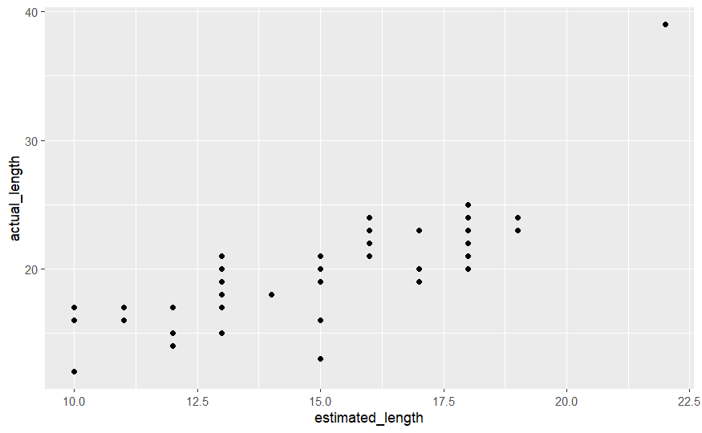

```
Correlation coefficient and interpret value
```

| cor(estimated_length, actual_length) |
| --- |
| 0.8046597 |

Interpretation. The previous plot suggested a positive correlation between the two variables.The correlation coefficient not only indicate that this correlation is positive but also by its magnitude is `very strong`. So the correlation is very strong.

```
Linear regression..
```

actual_length (dependent variable *y*),estimated_length (independent variable *X*) Note: linear_regression2 was a `practice` about altered the X -Y variable

```r
summary(linear_regression)
```

```
Call:
lm(formula = actual_length ~ estimated_length, data = project)

Residuals:
    Min      1Q  Median      3Q     Max
-6.7687 -1.6513  0.1195  1.1252 10.6669

Coefficients:
                 Estimate Std. Error t value Pr(>|t|)
(Intercept)        1.4164     2.0069   0.706    0.484
estimated_length   1.2235     0.1303   9.389 1.91e-12 ***
---
Signif. codes:  0 ‘***’ 0.001 ‘**’ 0.01 ‘*’ 0.05 ‘.’ 0.1 ‘ ’ 1

Residual standard error: 2.606 on 48 degrees of freedom
Multiple R-squared:  0.6475,    Adjusted R-squared:  0.6401
F-statistic: 88.16 on 1 and 48 DF,  p-value: 1.911e-12
```

Interpretation.

Previous plot indicates that if the independent variable is the estimated_length there is a strong correlation. The R-squared coefficient is close to 1 than to 0. So, in my opinion, the regression model indicate that the previous observation about the relationship between variables is correct. In terms of slope, 1 unit of increase in the estimated_length (independent variable) changes the actual_length (dependent variable) by 1.22 units. Question, if the ideal relation is 1 : 1, is better 0.78 or 1.22?

```
p-value
```

| term | estimate | std.error | statistic | p.value |
| --- | --- | --- | --- | --- |
| (Intercept) | 1.416379 | 2.0069491 | 0.7057375 | 4.837627e-01 |
| estimated_length | 1.223489 | 0.1303049 | 9.3894314 | 1.911284e-12 |

| term | estimate | std_error | statistic | p_value |
| --- | --- | --- | --- | --- |
| (Intercept) | 1.416379 | 2.0069491 | 0.7057375 | 4.837627e-01 |
| estimated_length | 1.223489 | 0.1303049 | 9.3894314 | 1.911284e-12 |

| r_squared | adj_r_squared | sigma | statistic | p_value | df | log_lik | aic | bic | deviance | df_residual | nobs |
| --- | --- | --- | --- | --- | --- | --- | --- | --- | --- | --- | --- |
| 0.6474772 | 0.640133 | 2.606163 | 88.16142 | 1.911284e-12 | 1 | -117.8203 | 241.6407 | 247.3767 | 326.0201 | 48 | 50 |

For interpret p-value I have to do a diagnosis plot

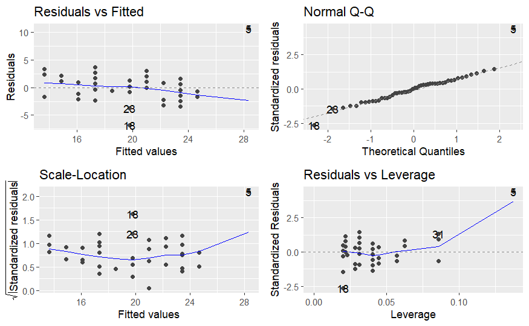

Plots: Residuals-Fitted,shows a deviation of -2.5 from 0, Normal Q-Q , the points are in the line - except one `outliner`- so is a normal distribution. The plot is fine,  
Scale-location, looks fine because is over x axis(positive) Residuals vs Leverage should be around 0 but the `outliner` make a deviation ?

2 Extension - Residuals vs Leverage

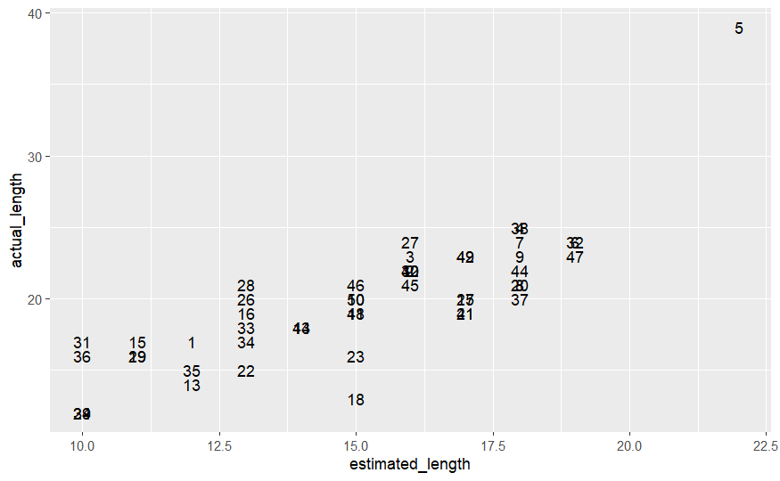

Cook’s distance

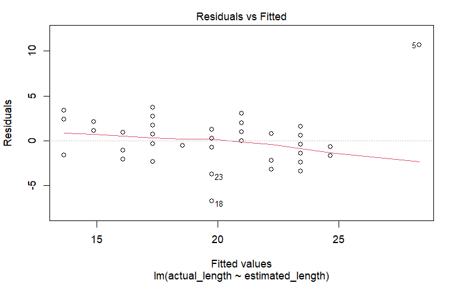

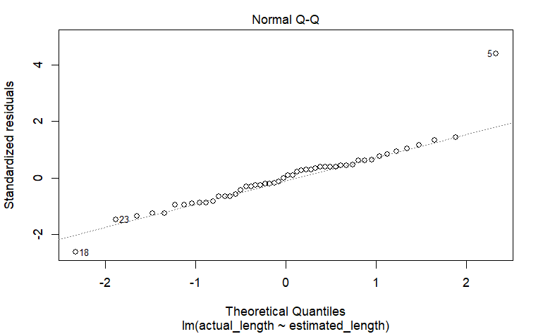

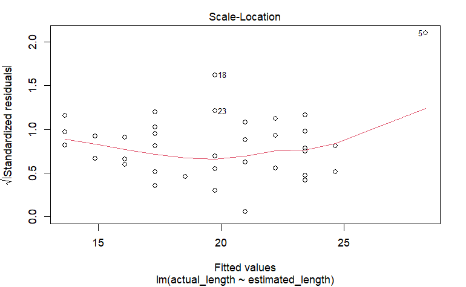

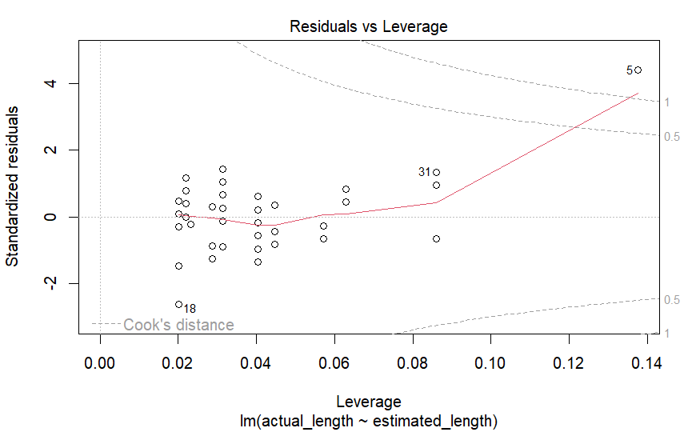

[output not shown]

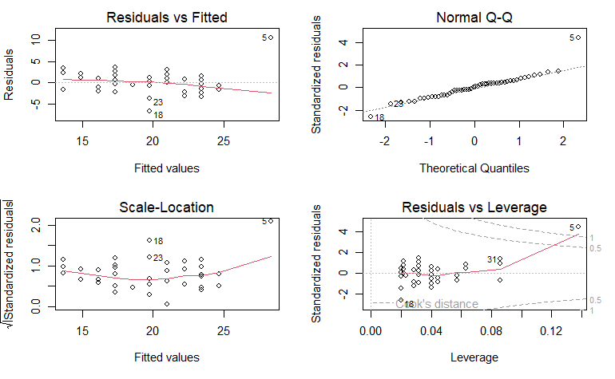

```r
par(mfrow = c(2,2))+
  plot(linear_regression)
```